# 04 Sanity Check Control Trial Performance

June 20, 2019

# 1 Overview

This notebook contains visualizations of performance on control trials (the analyses were performed at the individual level in the notebook `01_preprocessing_idv.Rmd`). In addition, this notebook contains visualizations of exclusions and inclusions (given that the same data are used).

# 2 Preliminaries

Before reading the data the following is specified:

```r
notebook_name <-
   stringr::str_to_lower(stringr::str_replace_all(params$title, " ", "_"))
```

- the *name of the notebook (`notebook_name`)*, which is used to save output to a notebook-specific directory

```r
# Data will be read from here --------------------------------------------------

# Directory containing preprocessed data
preprocessed_data_dir <-
  file.path("data","derivatives", "01_preprocessing")

# Directory containing preprocessed data from included participants only
preprocessed_included_data_dir <-
  file.path(preprocessed_data_dir, "included")

# Data will be written here ----------------------------------------------------

# Derived data will be written here
data_derivatives_dir <-
  file.path("data","derivatives", notebook_name)

# Figures will be written here
figures_dir <-
  file.path("figures", notebook_name)

# Create non-existing dirs if they don't exist
cmdsddfeitc::check_dir(all_dirs = c(data_derivatives_dir, figures_dir))
```

- all *relevant directories* for reading and writing data

```r
# File names of benchmark data, all participants
benchmark_all_filenames <- list.files(path = preprocessed_data_dir,
                                      pattern = sprintf("^benchmark_results_task-%s.*.csv$",
                                                        params$task[[1]]),
                                      recursive = TRUE
                                      )

# File names of benchmark data, included participants only
benchmark_included_filenames <-
  list.files(path = preprocessed_included_data_dir,
             pattern = sprintf("^benchmark_results_task-%s.*.csv$",
                               params$task[[1]])
             )
```

- the names of the files containing benchmark data (including control trial performance descriptives from calibration and experiment task) from all participants (`benchmark_all_filenames`) and the subset of included participants (`benchmark_included_filenames`)

# 3 Read data

Having specified all relevant variables, the benchmark data (generated by the notebook `01_preprocessing.Rmd`) are read:

```r
# Read the data, using task-dependent column specifications

# Benchmark data - all
benchmark_all_data <- tibble::tibble()

for (i_file in 1:length(benchmark_all_filenames)) {
  benchmark_all_data <-
    dplyr::bind_rows(benchmark_all_data,
                     readr::read_csv(file = file.path(preprocessed_data_dir, benchmark_all_filenames[[i_file]]),
                                     col_types = cmdsddfeitc::get_col_types("benchmark_data"))
                     )
}

# Benchmark data - included
benchmark_included_data <- tibble::tibble()

for (i_file in 1:length(benchmark_included_filenames)) {
  benchmark_included_data <-
    dplyr::bind_rows(benchmark_included_data,
                     readr::read_csv(file = file.path(preprocessed_included_data_dir, benchmark_included_filenames[[i_file]]),
                                     col_types = cmdsddfeitc::get_col_types("benchmark_data"))
                     )
}
```

# 4 Preprocess data

The benchmark data are analyzed for two purposes:

1. visualization of performance on control trials
2. visualizations of exclusions and inclusions

For the first purpose, benchmark data from included participants (`benchmark_included_data`) are tidied and prepared for plotting.

```r
# Tidy the benchmark_included_data data, so that it's ready for plotting
benchmark_included_data_tidy <-
  benchmark_included_data %>%
  dplyr::filter(!(criterion %in% c("n_trial",
                                   "max_n_standard_trials_ms_greater_than_ml",
                                   "max_proportion_any_choice")),
                stage_id == "experiment") %>%
  # These columns have no added value anymore (all rows have stage_id = experiment & criterion_met = TRUE)
  dplyr::select(-criterion_met, stage_id) %>%
  # To make plotting easier, frame control trial accuracy as error rate (i.e. 1 - accuracy) for compatibility with other measures
  tidyr::spread(key = criterion, value = value) %>%
  dplyr::mutate(proportion_control_error = 1 - accuracy_control) %>%
  # These columns are now redundant
  dplyr::select(-accuracy_control) %>%
  tidyr::gather(key = "criterion",
                value = "value",
                proportion_control_error, proportion_too_fast,
                proportion_omission_error) %>%
  # Relabel, for plotting purposes
  dplyr::mutate(participant_id = factor(participant_id),
                criterion = factor(criterion,
                                   levels = c("proportion_too_fast",
                                              "proportion_omission_error",
                                              "proportion_control_error"),
                                   labels = c("Fast responses",
                                              "Omission errors",
                                              "Commission errors"
                                              ),
                                   ordered = TRUE
                                   )
                )

# Print for inspection
benchmark_included_data_tidy %>% dplyr::arrange(participant_id, criterion)
```

| participant_id | stage_id | criterion | value |
| --- | --- | --- | --- |
| 9 | experiment | Fast responses | 0.023809524 |
| 9 | experiment | Omission errors | 0.007936508 |
| 9 | experiment | Commission errors | 0.000000000 |
| 11 | experiment | Fast responses | 0.123015873 |
| 11 | experiment | Omission errors | 0.000000000 |
| 11 | experiment | Commission errors | 0.000000000 |
| 13 | experiment | Fast responses | 0.087301587 |
| 13 | experiment | Omission errors | 0.000000000 |
| 13 | experiment | Commission errors | 0.000000000 |
| 15 | experiment | Fast responses | 0.000000000 |

[output cut: 74 more lines]

For the second purpose, benchmark data from both excluded and included participants (`benchmark_all_data`) are preprocessed. Specifically, I:

- identify participants belonging to the following mutually exclusive groups:
  - failed performance criteria on the calibration task (`lt_failed_calibration`);
  - failed performance criteria on the experimental task (`lt_failed_experiment`);
  - was affected by the technical error (`lt_affected_by_technical_error`);
  - was included in the analysis (`lt_included_in_analysis`).
- summarize group counts in a tibble (`sankey_data`) for plotting

Note: `lt_failed_experiment` takes precedence over `lt_affected_by_technical_error`.

```r
# Identify groups --------------------------------------------------------------

# We identify 4 groups, for each we make a lookup table

# Group 1 - participants who failed calibration task performance criteria
lt_failed_calibration <-
  benchmark_all_data %>%
  # Identify these participants by identifying fail the n_trial criterion for
  # the experiment (i.e. n_trial = 0)
  dplyr::filter(stage_id == "experiment", criterion == "n_trial") %>%
  dplyr::select(participant_id, criterion_met) %>%
  dplyr::mutate(failed_calibration = ifelse(!criterion_met,
                                            "Y",
                                            "N")) %>%
  dplyr::mutate(task = params$task) %>%
  dplyr::select(participant_id, task, failed_calibration)

# Group 2 - participants who failed experiment task performance criteria
lt_failed_experiment <-
  benchmark_all_data %>%
  dplyr::filter(stage_id == "experiment", criterion %in% c("accuracy_control",
                                                           "proportion_too_fast",
                                                           "proportion_omission_error",
                                                           "max_proportion_any_choice")
                ) %>%
  dplyr::group_by(participant_id) %>%
  dplyr::summarize(failed_experiment = ifelse(!all(criterion_met),
                                              "Y",
                                              "N"
                                              )) %>%
  dplyr::arrange(participant_id)


# Group 3 - participants who were affected by a technical error in the task

# Note that failure to meet performance criteria (control trials) takes
# precendence over technical error (which affected standard trials only)
pid_failed_calibration_or_experiment <-
  dplyr::left_join(lt_failed_calibration,
                   lt_failed_experiment,
                   by = "participant_id") %>%
  dplyr::filter((failed_calibration == "Y") | (failed_experiment == "Y")) %>%
  dplyr::pull(participant_id)

lt_affected_by_technical_error <-
  benchmark_all_data %>%
  dplyr::filter(!(participant_id %in% pid_failed_calibration_or_experiment),
                stage_id == "experiment",
                criterion == "max_n_standard_trials_ms_greater_than_ml") %>%
  dplyr::mutate(affected_by_tecnical_error = ifelse(!criterion_met,
                                                    "Y",
                                                    "N")
                ) %>%
  dplyr::select(participant_id, affected_by_tecnical_error) %>%
  dplyr::arrange(participant_id)

# Group 4 - participants who were included in the analysis

lt_included_in_analysis <-
  benchmark_included_data %>%
  dplyr::filter(stage_id == "experiment", criterion == "n_trial") %>%
  dplyr::mutate(included = ifelse(criterion_met,
                                  "Y",
                                  "N")
                ) %>%
  dplyr::select(participant_id, included)

# Join tibbles together for plotting -------------------------------------------

sankey_data <-
  dplyr::left_join(lt_failed_calibration,
                   lt_included_in_analysis,
                   by = "participant_id") %>%
  dplyr::left_join(.,
                   lt_failed_experiment,
                   by = "participant_id") %>%
  dplyr::left_join(.,
                   lt_affected_by_technical_error,
                   by = "participant_id") %>%
  # Replace NAs with meaningful labels, depending on column
  tidyr::replace_na(list(included = "N",
                         failed_calibration = "NA",
                         failed_experiment = "NA",
                         affected_by_tecnical_error = "NA")) %>%
  dplyr::arrange(participant_id) %>%
  dplyr::select(participant_id, task, failed_calibration, failed_experiment,
                affected_by_tecnical_error, included) %>%
  dplyr::group_by(task, failed_calibration, failed_experiment,
                  affected_by_tecnical_error, included) %>%
  # Compute frequencies
  dplyr::summarize(freq = n()) %>%
  dplyr::ungroup() %>%
  # Make group labels for plotting purposes
  dplyr::mutate(grp_label =
                  ifelse(included == "Y",
                         "included",
                         ifelse(affected_by_tecnical_error == "Y",
                                "technical_error",
                                ifelse((failed_calibration == "N") &
                                         (failed_experiment == "Y"),
                                       "failed_experiment",
                                       ifelse(failed_calibration == "Y",
                                              "failed_calibration",
                                              NA)
                                       )
                                )
                         )
                ) %>%
  # Convert variables to factors to make sure that plot looks like as desired
  dplyr::mutate(failed_calibration = factor(failed_calibration,
                                            levels = c("N", "Y"),
                                            labels = c("N", "Y"),
                                            ordered = TRUE),
                failed_experiment = factor(failed_experiment,
                                           levels = c("Y", "N", "NA"),
                                           labels = c("Y", "N", "NA"),
                                           ordered = TRUE),
                affected_by_tecnical_error = factor(affected_by_tecnical_error,
                                           levels = c("Y", "N", "NA"),
                                           labels = c("Y", "N", "NA"),
                                           ordered = TRUE),
                included = factor(included,
                                  levels = c("N", "Y"),
                                  labels = c("N", "Y"),
                                  ordered = TRUE),
                grp_label =
                  factor(grp_label,
                         levels = c("included", "failed_calibration",
                                    "failed_experiment", "technical_error"),
                         labels = c("included", "failed calibration",
                                    "failed experiment", "technical error")
                         # ordered = TRUE)
                  )
  )

# Print for inspection
sankey_data %>% dplyr::arrange(dplyr::desc(freq))
```

| task | failed_calibration | failed_experiment | affected_by_tecnical_error | included | freq | grp_label |
| --- | --- | --- | --- | --- | --- | --- |
| defer_speedup | N | N | N | Y | 28 | included |
| defer_speedup | N | N | Y | N | 8 | technical error |
| defer_speedup | Y | NA | NA | N | 7 | failed calibration |
| defer_speedup | N | Y | NA | N | 2 | failed experiment |

# 5 Visualize data

In section 2.2. of the preregistration, we listed the exclusion criteria after study enrollment, including:

1. accuracy < 75% on catch trials and instruction manipulation check trials (see also section 2.6.1. of preregistration)
2. no response on > 25% of standard intertemporal choice trials
3. fast response time (< 1500 ms) on 25% of standard intertemporal choice trials

Figure 5.1 shows these criteria as commission error rate (criterion 1, note than minimum of 75% accuracy means maximum 25% errors), omission error rate (criterion 2), and fast response rate (criterion 3).

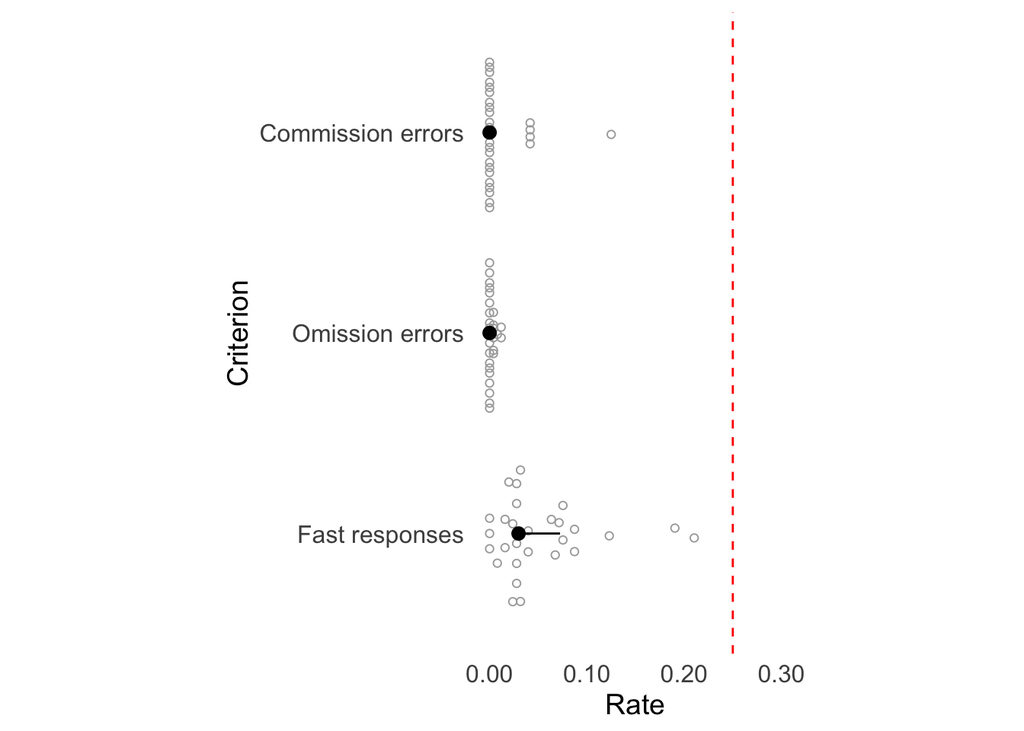

Figure 5.1: Rates of commission errors on control (catch) trials, omission errors (response failures), and fast (< 1.5 s) responses. For each variable, individual data (grey open circles), group median (black filled circle), and interquartile range (black line) is shown. Red dashed line indicates the maximum permissable rate, above which participants were excluded.

```r
# Source: https://stackoverflow.com/questions/10035786/ggplot2-y-axis-label-decimal-precision
fmt_dcimals <- function(decimals=0){
   # return a function responpsible for formatting the
   # axis labels with a given number of decimals
   function(x) format(x,nsmall = decimals,scientific = FALSE)
}

expt_control_trial_performance <-
  ggplot2::ggplot(benchmark_included_data_tidy,
                  mapping = ggplot2::aes(x = criterion,
                                         y = value)) +
    ggbeeswarm::geom_quasirandom(color = "darkgrey",
                                 shape = 21) +

    # Red dashed line represents the value above which a participant would be excluded
    ggplot2::geom_hline(yintercept = 0.25,
                        color = "red",
                        linetype = "dashed") +
    ggplot2::stat_summary(fun.ymin = function(z) {quantile(z, 0.25)},
                          fun.ymax = function(z) {quantile(z, 0.75)},
                          fun.y = median
                          ) +
    ggplot2::coord_flip() +
    ggplot2::scale_x_discrete(name = "Criterion") +
    ggplot2::scale_y_continuous(name = "Rate",
                                limits = c(0,.3),
                                breaks = seq(0,.3,.1),
                                labels = fmt_dcimals(2)) +

    cmdsddfeitc::theme_cmfsddfeitc() +
    ggplot2::theme(aspect.ratio = 2,
                   panel.background = ggplot2::element_rect(fill = "white"))

expt_control_trial_performance
```

```r
if (params$task == "defer_speedup") {
  ctrl_trials <- "catch"
} else if (params$task == "date_delay") {
  ctrl_trials <- "catch and instruction manipulation check"
}

cap_expt_control_trial_performance <- sprintf("Rates of commission errors on control (%s) trials, omission errors (response failures), and fast (< 1.5 s) responses. For each variable, individual data (grey open circles), group median (black filled circle), and interquartile range (black line) is shown. Red dashed line indicates the maximum permissable rate, above which participants were excluded.", ctrl_trials)
```